# Part II - Parameters that allow us to identify Possible Loan Defaults

## Investigation Overview

When a person comes across a Dataset with over 100 thousand Loans and notices that only 66% of the Closed Loans were "Completed", i.e Paid off in full, then one must wonder "What could possibly cause a third of all Borrowers to Default?". Some points to look into are obvious, but necessary to check, such as the Borrowers Monthly Income and their Loan Amount, some points we have to look deeper, like how much lower APR the higer Ratings unlock and how Debt to Income Ratio trends between Defaulters or Payers.

## Dataset Overview

Our Dataset comes from the Peer-to-peer Lending Company, Prosper Loans. It contains over 100k rows of information regarding Loans with a lot of useful Information for Analysis.

```python
# import all packages and set plots to be embedded inline
import numpy as np
import pandas as pd
import matplotlib.pyplot as plt
import seaborn as sb
from sklearn import linear_model
import statsmodels.api as sm

%matplotlib inline

# suppress warnings from final output
import warnings
warnings.simplefilter("ignore")
```

```python
clean_copy = pd.read_csv('clean_copy.csv')
positive_outcome = pd.read_csv('positive_outcome.csv')
positive_sample = pd.read_csv('positive_sample.csv')
negative_outcome = pd.read_csv('negative_outcome.csv')
negative_sample = pd.read_csv('negative_sample.csv')
```

## Borrower APR divided per Prosper Ratings

When we try to figure out Why so many loans were defaulted or charged off, we should look into what makes a loan harder to pay off. A good starting point is the APR, defined as "refers to the yearly interest generated by a sum that's charged to borrowers or paid to investors". Higher APR's incur more Interest, thus making it harder to pay a loan off. Having a good Credit grade or Prosper Rating can help unlock the better tier's of APR's, as depicted in these ilustrative Violin Plots. Easily observable is that the bulk of 'HR' had an APR of 0.35 while "AA" hovered around 0.1!

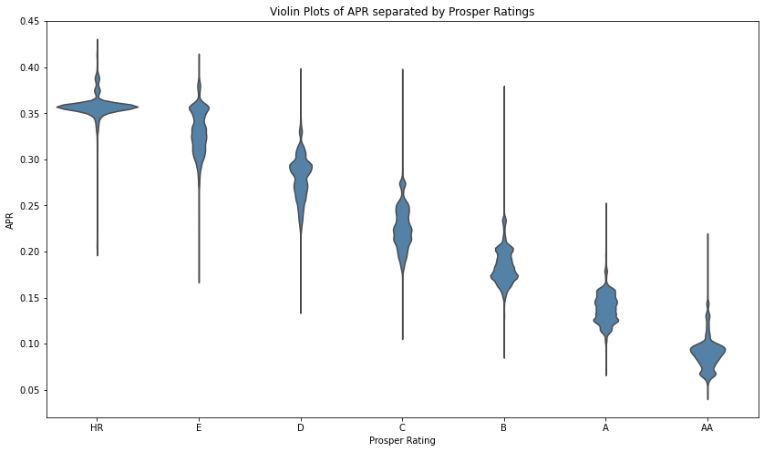

```python
#ordering of Ratings
ordinal_var_dict = {'creditgrade': ['HR','E','D','C','B','A','AA'],
                    'prosperrating': ['HR','E','D','C','B','A','AA']}

for var in ordinal_var_dict:
        ordered_var = pd.api.types.CategoricalDtype(ordered = True,
                                                    categories = ordinal_var_dict[var])
        clean_copy[var] = clean_copy[var].astype(ordered_var)

plt.figure(figsize=(14,8))
ax = sb.violinplot(data=clean_copy,x='prosperrating',y='borrowerapr',color='steelblue',inner=None)
ax.set_xlabel('Prosper Rating')
ax.set_ylabel('APR')
ax.set_title('Violin Plots of APR separated by Prosper Ratings');
```

## Loan Amount vs Stated Monthly Income

Two other deciding factors of a Loan being paid off or not are the Loan's original Amount, which in our dataset varies from around 10k Dollars for lower Ratings to upwards of 30k Dollars for the higher Ratings, and the declared Monthly Income. Plotting one against the other gives us a good view of the trend of how well the Borrowers faired in paying off their loans.

The datasets were filtered to only verifiable incomes of under 20k Dollars/Month and divided into Positive and negative Outcomes.

Also, to actually make sense of the information, I fitted a Least squares polynomial fit with numpy's Polyfit function. Once plotted they provide valuable information, that being the Borrowers who Defaulted or Charged Off had, on average, a higher Loan Amount to Monthly income Ratio than their "Completed" counterparts.

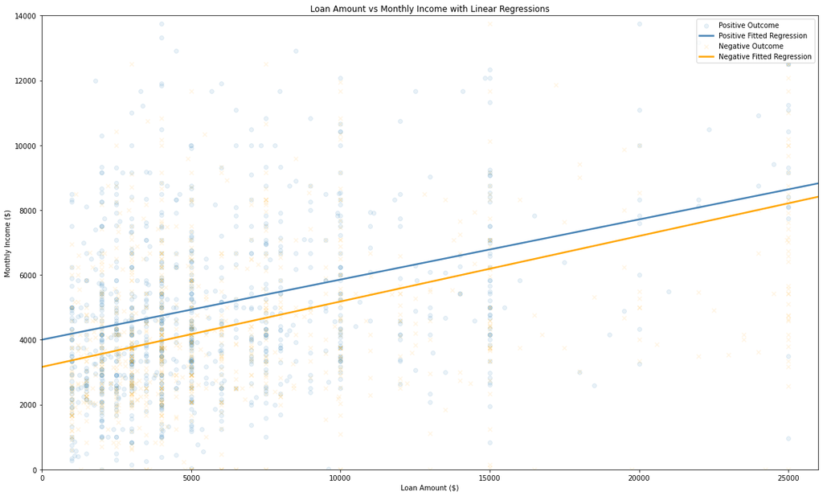

```python
#Fitting a Linear Regression
xseq = np.linspace(0, 30000)
b, a = np.polyfit(positive_outcome.loanoriginalamount,positive_outcome.statedmonthlyincome, deg=1)
b2, a2 = np.polyfit(negative_outcome.loanoriginalamount,negative_outcome.statedmonthlyincome, deg=1)

#plotting in blue and orange instead of blue and red for colorblind visibility
plt.figure(figsize=(20,12))
plt.scatter(x='loanoriginalamount',y='statedmonthlyincome',alpha=0.1,data=positive_sample,marker='o')
plt.plot(xseq, a + b * xseq, color="steelblue", lw=2.5)
plt.scatter(x='loanoriginalamount',y='statedmonthlyincome',alpha=0.1,data=negative_sample,marker='x',color='orange')
plt.plot(xseq, a2 + b2 * xseq, color='orange', lw=2.5)
plt.xlabel("Loan Amount ($)")
plt.ylabel("Monthly Income ($)")
plt.legend(['Positive Outcome','Positive Fitted Regression','Negative Outcome','Negative Fitted Regression'],
           loc="upper right")
plt.title('Loan Amount vs Monthly Income with Linear Regressions')
plt.ylim(0,14000)
plt.xlim(0,26000);
```

## Debt to Income Ratio

Another valid Metric to observe is a Borrowers Debt to Income Ratio. We could think of it as a "crippling" factor of the Borrowers Monthly Income, since they would have to dedicate a portion of said Income already to pre-existing Debt.

Here I opted to plot through lines and separated by the Borrowers States, limiting to 20 since 50 points would be hard to visualize. Once again I've plotted both for Positive and Negative outcomes so we can easily see how well a Higher Debt to Income Ratio can assist in predicting if a Borrower will be Sucessful in paying off or not their Loan.

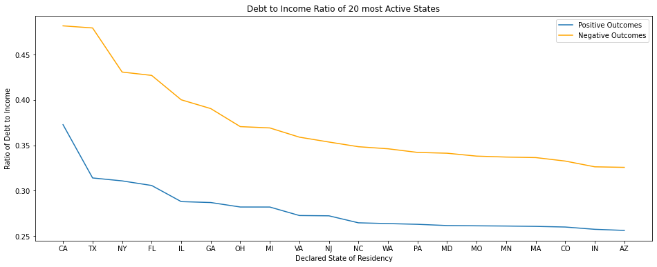

```python
#filtering 20 most active states
active_states = clean_copy.borrowerstate.value_counts().head(20).index

plt.figure(figsize=(16,6))


#plotting two lineplots over each other for positive and negative outcomes
ax1 = sb.lineplot(data=positive_outcome.groupby('borrowerstate').mean()['debttoincomeratio'].reset_index()\
            .sort_values(by='debttoincomeratio',ascending=False).head(20),
            x=active_states,y='debttoincomeratio')
plt.ylabel('Ratio of Debt to Income')
plt.title('Debt to Income Ratio of 20 most Active States')


ax2 = sb.lineplot(data=negative_outcome.groupby('borrowerstate').mean()['debttoincomeratio'].reset_index()\
            .sort_values(by='debttoincomeratio',ascending=False).head(20),
            x=active_states,y='debttoincomeratio',color='orange')
plt.ylabel('Ratio of Debt to Income')
plt.xlabel('Declared State of Residency')
plt.legend(('Positive Outcomes','Negative Outcomes'));
```

## Conclusions

Through our dataset we were able to identify very strong Factors that can help us predict if a Borrower might default or not. Although I'm certain that there is still some profitability in Defaults and Charge offs, such as when the Loan is charged off to a collections company, we could use the information we obtained to fit multi variable Regressions to help us predict Outcomes and, if desired, try to minimize Negative Outcome Loans. For now, I believe we can easily say that our Culprit for around a third of the Closed Loans being a Negative Outcome is strongly correlated to a Factor of High APR, High Debt to Income Ratio and High Loan amount compared to Monthly Income.

```python
!jupyter nbconvert Part_II_slide_deck.ipynb --to slides --post serve --no-input --no-prompt
```

[output not shown]